# Task1_Luqman_SciLife2026

# Task 7 - Basic visualization with R

#The nummenmaa-package mentioned within the examples can be installed with the code below if you wish to try some of the examples yourself. #install.packages(“remotes”) #install_url(“http://emotion.utu.fi/wp-content/uploads/2019/11/nummenmaa_1.0.tar.gz”,dependencies=TRUE)

#1. Compare the distributions of the body heights of the two species from the ‘magic_guys.csv’ dataset graphically #I am a bit confused on what body height means, just the length?

```r
setwd("/Users/luqman/Postdoc/KI-RIKEN bioinfo course") #set working directory to save
magic_guys <- read.csv("magic_guys.csv") #import dataset 'magic_guys.csv'
head(magic_guys) #check rows and columns
```

|  | uniqId | species | length | weight |
| --- | --- | --- | --- | --- |
| 1 | p1 | jedi | 174.6 | 71.3 |
| 2 | p2 | jedi | 252.2 | 70.8 |
| 3 | p3 | jedi | 229.8 | 70.7 |
| 4 | p4 | jedi | 176.2 | 80.4 |
| 5 | p5 | jedi | 213.3 | 82.0 |
| 6 | p6 | jedi | 112.5 | 64.2 |

```r
#a. using the basic 'hist' function as well as ‘ggplot’ and ‘geom_histogram’ functions from the ggplot2 package. Optimize the plots for example by trying several different 'breaks'. Note that ggplot2-based functions give you many more options for changing the visualization parameters, try some of them.

library(ggplot2) #load ggplot2

unique(magic_guys$species) #extract species names
```

```
## [1] "jedi" "sith"
```

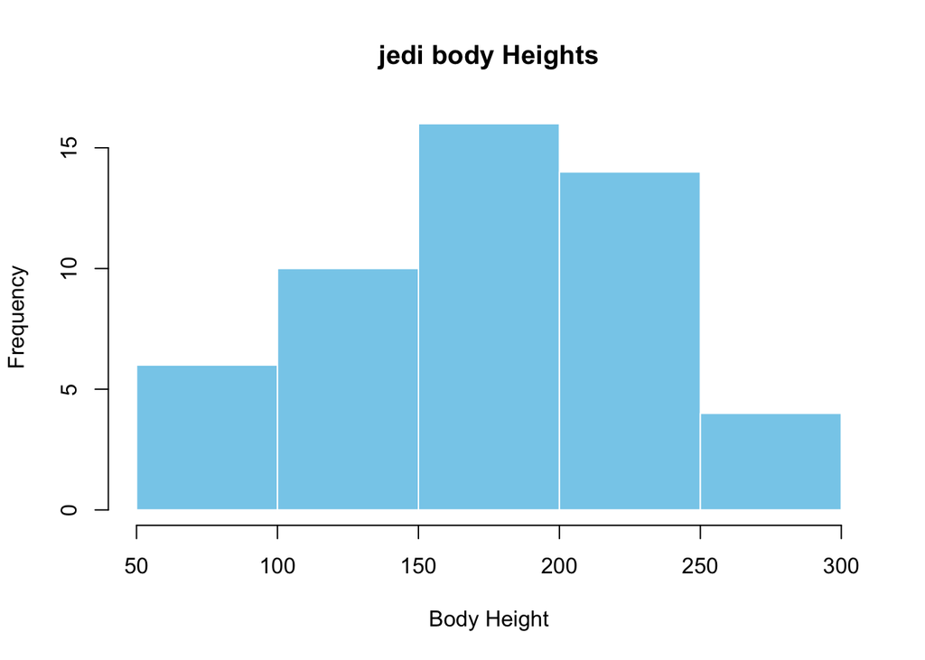

```r
setwd("/Users/luqman/Postdoc/KI-RIKEN bioinfo course") #set working directory to save

#hist jedi function
hist(
  magic_guys[magic_guys[, 2] == "jedi", 3],
  breaks = 6,
  col = "skyblue",
  border = "white",
  main = "jedi body Heights",
  xlab = "Body Height",
  ylab = "Frequency"
)
```

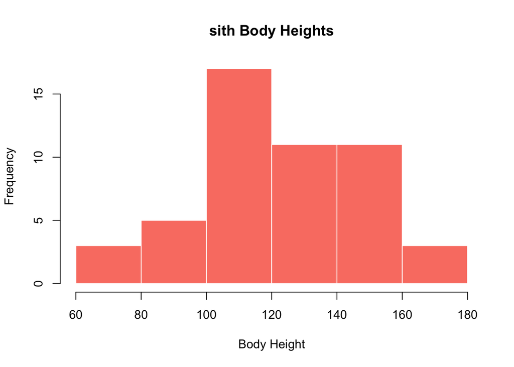

```r
#hist  sith function
hist(
  magic_guys[magic_guys[, 2] == "sith", 3],
  breaks = 5,
  col = "salmon",
  border = "white",
  main = "sith Body Heights",
  xlab = "Body Height",
  ylab = "Frequency"
)
```

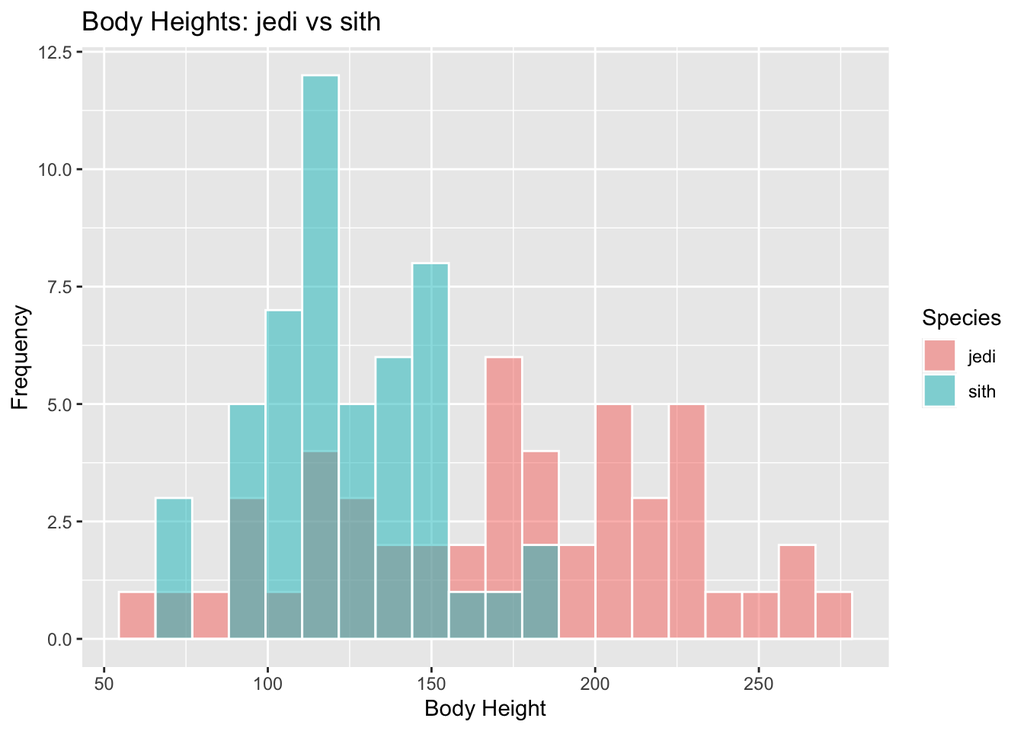

```r
#ggplot2

ggplot(magic_guys,
       aes(x = .data[[names(magic_guys)[3]]],
           fill = .data[[names(magic_guys)[2]]])) +
  geom_histogram(
    bins = 20, #more bins for a wider distribution
    color = "white",
    alpha = 0.5,
    position = "identity"
  ) +
  labs(
    title = "Body Heights: jedi vs sith",
    x = "Body Height",
    y = "Frequency",
    fill = "Species"
  )
```

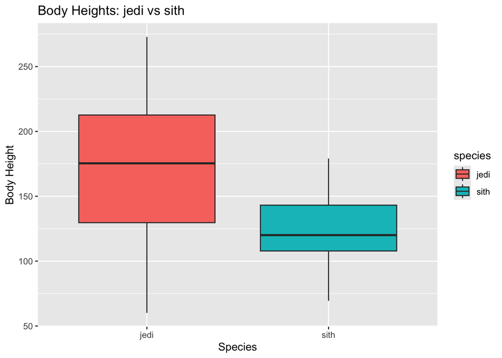

```r
#b. Do the same comparison as in a. but with boxplots. If you want to use the ggplot2-package, use the functions ‘ggplot’ and ‘geom_boxplot’.

ggplot(magic_guys,
       aes(x = .data[[names(magic_guys)[2]]],
           y = .data[[names(magic_guys)[3]]],
           fill = .data[[names(magic_guys)[2]]])) +
  geom_boxplot() +
  labs(
    title = "Body Heights: jedi vs sith",
    x = "Species",
    y = "Body Height"
  )
```

```r
#c. Save the plots with the ‘png’, ‘pdf’, and ‘svg’ formats. In which situation would you use which file format?

ggsave("boxplot_jedi_sith.pdf"); ggsave("boxplot_jedi_sith.png", dpi = 300); ggsave("boxplot_jedi_sith.svg")
#Answer: png is suitable as an uneditable image since it has lower resolution, pdf is suitable for final standard figure, while svg vector image is good for further editing.
```

#Task 8

#1. Install the Tidybiology package, which includes the data ‘chromosome’ and ‘proteins’

remotes::install_github( “hirscheylab/tidybiology”, dependencies = TRUE )

#a. Extract summary statistics (mean, median and maximum) for the following variables from the ‘chromosome’ data: variations, protein coding genes, and miRNAs. Utilize the tidyverse functions to make this as simply as possible.

```r
library(tidyverse)
library(tidybiology)

data("chromosome")
data("proteins")

# Check the datasets
glimpse(chromosome)
```

```
## Rows: 24
## Columns: 14
## $ id                     <fct> 1, 2, 3, 4, 5, 6, 7, 8, 9, 10, 11, 12, 13, 14, …
## $ length_mm              <dbl> 85, 83, 67, 65, 62, 58, 54, 50, 48, 46, 46, 45,…
## $ basepairs              <dbl> 248956422, 242193529, 198295559, 190214555, 181…
## $ variations             <dbl> 12151146, 12945965, 10638715, 10165685, 9519995…
## $ protein_codinggenes    <int> 2058, 1309, 1078, 752, 876, 1048, 989, 677, 786…
## $ pseudo_genes           <int> 1220, 1023, 763, 727, 721, 801, 885, 613, 661, …
## $ totallongnc_rna        <int> 1200, 1037, 711, 657, 844, 639, 605, 735, 491, …
## $ totalsmallnc_rna       <int> 496, 375, 298, 228, 235, 234, 208, 214, 190, 20…
## $ mi_rna                 <int> 134, 115, 99, 92, 83, 81, 90, 80, 69, 64, 63, 7…
## $ r_rna                  <int> 66, 40, 29, 24, 25, 26, 24, 28, 19, 32, 24, 27,…
## $ sn_rna                 <int> 221, 161, 138, 120, 106, 111, 90, 86, 66, 87, 7…
## $ sno_rna                <int> 145, 117, 87, 56, 61, 73, 76, 52, 51, 56, 76, 6…
## $ miscnc_rna             <int> 192, 176, 134, 104, 119, 105, 143, 82, 96, 89, …
## $ centromereposition_mbp <dbl> 125.0, 93.3, 91.0, 50.4, 48.4, 61.0, 59.9, 45.6…
```

```r
glimpse(proteins)
```

```
## Rows: 20,430
## Columns: 8
## $ uniprot_id       <chr> "P04217", "Q9NQ94", "P01023", "A8K2U0", "U3KPV4", "Q9…
## $ gene_name        <chr> "A1BG", "A1CF", "A2M", "A2ML1", "A3GALT2", "A4GALT", …
## $ gene_name_alt    <chr> NA, "ACF ASP", "CPAMD5 FWP007", "CPAMD9", "A3GALT2P I…
## $ protein_name     <chr> "Alpha-1B-glycoprotein ", "APOBEC1 complementation fa…
## $ protein_name_alt <chr> "Alpha-1-B glycoprotein)", "APOBEC1-stimulating prote…
## $ sequence         <chr> "MSMLVVFLLLWGVTWGPVTEAAIFYETQPSLWAESESLLKPLANVTLTCQAH…
## $ length           <dbl> 495, 594, 1474, 1454, 340, 353, 340, 546, 672, 399, 4…
## $ mass             <dbl> 54254, 65202, 163291, 161107, 38754, 40499, 39497, 59…
```

```r
#use pipes for shorter lines
chromosome %>%
  summarise(
    across(
      c(variations, protein_codinggenes, mi_rna),
      list(
        mean = ~mean(.x, na.rm = TRUE),
        median = ~median(.x, na.rm = TRUE),
        max = ~max(.x, na.rm = TRUE)
      )
    )
  )
```

| variations_mean | variations_median | variations_max | protein_codinggenes_mean | protein_codinggenes_median | protein_codinggenes_max | mi_rna_mean | mi_rna_median | mi_rna_max |
| --- | --- | --- | --- | --- | --- | --- | --- | --- |
| 6484572 | 6172346 | 12945965 | 849.9583 | 836 | 2058 | 73.16667 | 75 | 134 |

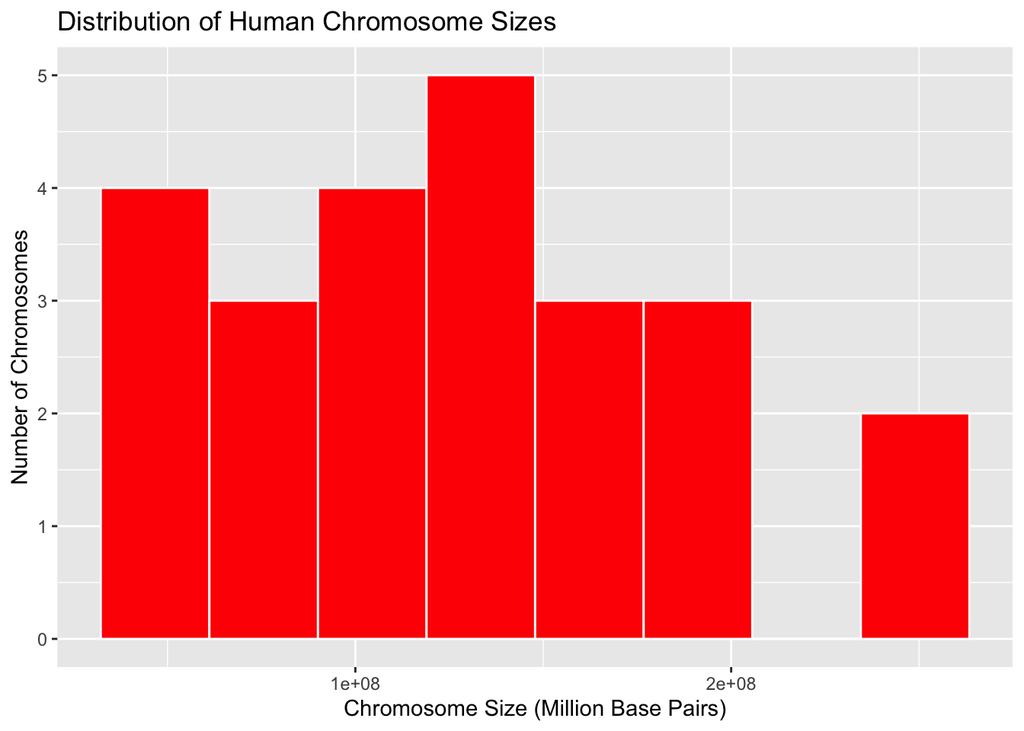

```r
#b. How does the chromosome size distribute? Plot a graph that helps to visualize this by using ggplot2 package functions.

#plot the graph
ggplot(chromosome, aes(x = basepairs)) +
  geom_histogram(
    bins = 8,
    fill = "red",
    color = "white"
  ) +
  labs(
    title = "Distribution of Human Chromosome Sizes",
    x = "Chromosome Size (Million Base Pairs)",
    y = "Number of Chromosomes"
  )
```

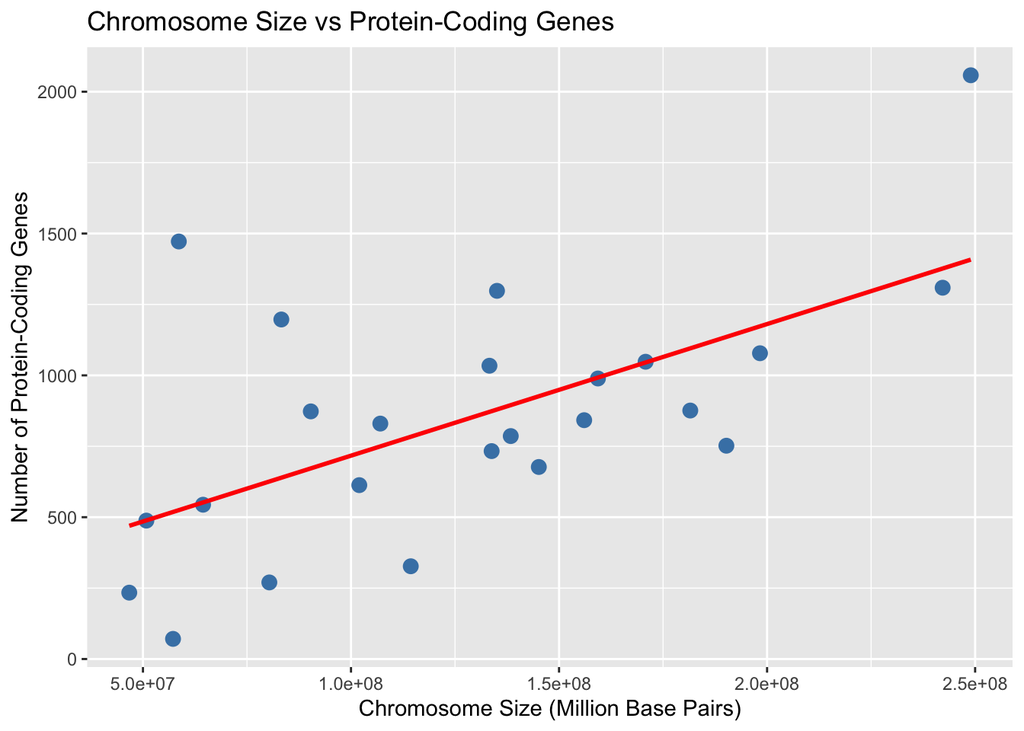

```r
#Answer: Two chromosomes are longer than the rest. The rest of the chromosomes show average distribution.

#c. Does the number of protein coding genes or miRNAs correlate with the length of the chromosome? Make two separate plots to visualize these relationships.

#Plot1, protein coding genes vs chomosome size
ggplot(chromosome,
       aes(x = basepairs, y = protein_codinggenes)) +
  geom_point(color = "steelblue", size = 3) +
  geom_smooth(method = "lm", se = FALSE, color = "red") +
  labs(
    title = "Chromosome Size vs Protein-Coding Genes",
    x = "Chromosome Size (Million Base Pairs)",
    y = "Number of Protein-Coding Genes"
  )
```

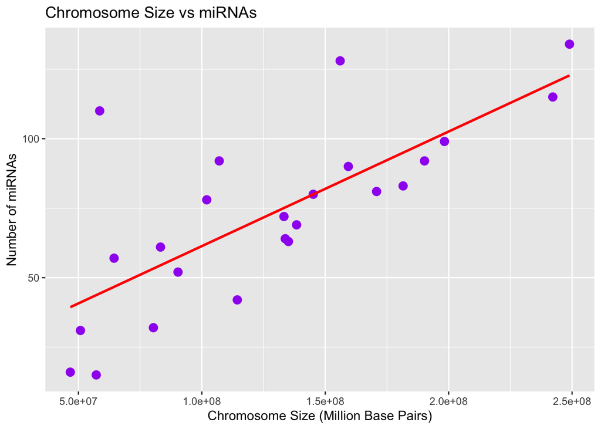

```r
#Plot2, miRNA vs chromosome size
ggplot(chromosome,
       aes(x = basepairs, y = mi_rna)) +
  geom_point(color = "purple", size = 3) +
  geom_smooth(method = "lm", se = FALSE, color = "red") +
  labs(
    title = "Chromosome Size vs miRNAs",
    x = "Chromosome Size (Million Base Pairs)",
    y = "Number of miRNAs"
  )
```

```r
#calculate correlation coefficient
cor(chromosome$basepairs,
    chromosome$protein_codinggenes,
    use = "complete.obs")
```

```
## [1] 0.6092793
```

```r
cor(chromosome$basepairs,
    chromosome$mi_rna,
    use = "complete.obs")
```

```
## [1] 0.7399229
```

```r
#Answer: both show positive correlation with chromosome size, albeit miRNA show higher correlation coeffecient.

#d. Calculate the same summary statistics for the ‘proteins’ data variables length and mass. Create a meaningful visualization of the relationship between these two variables by utilizing the ggplot2 package functions. Play with the colors, theme- and other visualization parameters to create a plot that pleases you.

#calculate mean, median, and maximum of length and mass
proteins %>%
  summarise(
    across(
      c(length, mass),
      list(
        mean = ~mean(.x, na.rm = TRUE),
        median = ~median(.x, na.rm = TRUE),
        max = ~max(.x, na.rm = TRUE)
      )
    )
  )
```

| length_mean | length_median | length_max | mass_mean | mass_median | mass_max |
| --- | --- | --- | --- | --- | --- |
| 557.1603 | 414 | 34350 | 62061.38 | 46140.5 | 3816030 |

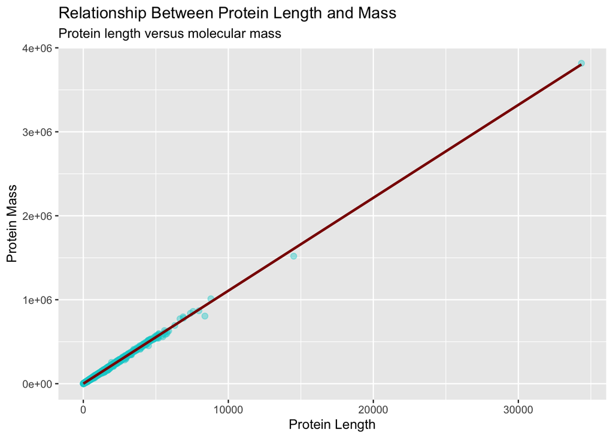

```r
#Visualize on plot

ggplot(proteins, aes(x = length, y = mass)) +
  geom_point(
    color = "darkturquoise",
    alpha = 0.4,
    size = 2
  ) +
  geom_smooth(
    method = "lm",
    color = "darkred",
    se = FALSE
  ) +
  labs(
    title = "Relationship Between Protein Length and Mass",
    subtitle = "Protein length versus molecular mass",
    x = "Protein Length",
    y = "Protein Mass"
  )
```

```r
#comment: In general, protein length and protein mass is proportional. There seems to be several proteins that are much longer than the others (outliers).
```